# MSDS 6306 Project Craft Breweries and Beers Analysis

Bethel Kumsa and Bosang Yun

7/4/2020

## Introduction & Dataset

Through this project we analyzed data regarding craft beers and corresponding breweries from the dataset provided. The Beers dataset contains a list of 2410 US craft beers and the Breweries dataset contains 558 US breweries.

```
## rgeos version: 0.5-3, (SVN revision 634)
##  GEOS runtime version: 3.7.2-CAPI-1.11.2
##  Linking to sp version: 1.4-1
##  Polygon checking: TRUE
```

## (1) Breweries by State

How many breweries are present in each state?

```r
breweriesState <- summary(as.factor(breweriesDataset$state))

breweriesState
```

```
##  AK  AL  AR  AZ  CA  CO  CT  DC  DE  FL  GA  HI  IA  ID  IL  IN  KS  KY  LA  MA
##   7   3   2  11  39  47   8   1   2  15   7   4   5   5  18  22   3   4   5  23
##  MD  ME  MI  MN  MO  MS  MT  NC  ND  NE  NH  NJ  NM  NV  NY  OH  OK  OR  PA  RI
##   7   9  32  12   9   2   9  19   1   5   3   3   4   2  16  15   6  29  25   5
##  SC  SD  TN  TX  UT  VA  VT  WA  WI  WV  WY
##   4   1   3  28   4  16  10  23  20   1   4
```

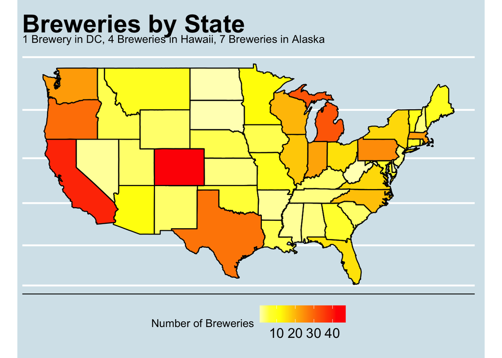

```r
breweriesState <- data.frame(abb = names(breweriesState), numBreweries = unname(breweriesState))
breweriesState$abb <- as.character(breweriesState$abb)
breweriesState$abb <- str_replace_all(breweriesState$abb, " ", "")

#Heatmap
lookup <- data.frame(abb = state.abb, region = tolower(state.name))
lookup$abb <- as.character(lookup$abb)
states <- map_data("state")

#There are 1 Brewery in DC, 4 Breweries in Hawaii, and 7 Breweries in Alaska not depicted on the map.
breweryByRegion <- merge(breweriesState, lookup, by = "abb", all.y = TRUE)
breweryMapDF <- merge(breweryByRegion, states, "region", all.y = TRUE)
breweryMapDF <- breweryMapDF [order(breweryMapDF$order),]

#Heatmap of breweries by state.
breweriesByStateHeatmap <- breweryMapDF %>% ggplot(aes(x=long,y=lat,group=group))+
  geom_polygon(aes(fill=numBreweries))+
  geom_path()+
  scale_fill_gradientn(colours=rev(heat.colors(10)),na.value="grey90") +
  coord_map()+
  ggtitle("Breweries by State") +
  labs(fill='Number of Breweries', subtitle = "1 Brewery in DC, 4 Breweries in Hawaii, 7 Breweries in Alaska") +
  theme_economist() +
  theme(plot.title = element_text(size=25),
        legend.position = "bottom",
        axis.title.x=element_blank(),
        axis.text.x=element_blank(),
        axis.ticks.x=element_blank(),
        axis.title.y =element_blank(),
        axis.text.y=element_blank(),
        axis.ticks.y=element_blank())

breweriesByStateHeatmap
```

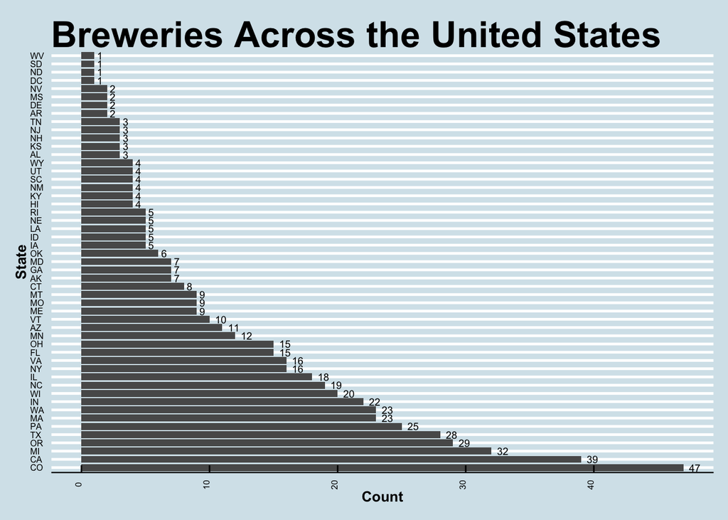

```r
#Horizontal Bar Graph
breweriesDataset %>% ggplot(mapping=aes(x=forcats::fct_infreq(state)))+
  geom_bar(position = position_dodge(width = 1), width=0.85)+
  stat_count(aes(label = ..count..), geom = "text",size=2.5, hjust = -0.5)+
  labs(y="Count", x = "State")+
  theme_economist()+
  theme(text = element_text(size=5),
        plot.title = element_text(size=25),
        axis.text.x = element_text(size=6, angle = 90),
        axis.text.y = element_text(size=6),
        axis.title=element_text(size=10,face="bold"))+
  coord_flip()+
  ggtitle("Breweries Across the United States")
```

## (2) Merging Original Beers and Breweries Data Sets

Merge beer data with the breweries data. Print the first 6 observations and the last six observations to check the merged file. (RMD only, this does not need to be included in the presentation or the deck.)

```r
beerAndBrew <- merge(breweriesDataset, beersDataset, by.x = "Brew_ID",by.y = "Brewery_id", all=TRUE)
names(beerAndBrew)[2] = "Brewery_Name"
names(beerAndBrew)[5] = "Beer_Name"
```

## (3) Address the Missing Values in Each Column

```r
missingVals <- is.na(beerAndBrew)
missingVals <- data.frame(Brew_ID = missingVals[,1], Brewery_Name = missingVals[,2], City = missingVals[,3],
           State = missingVals[,4], Beer_Name = missingVals[,5], Beer_ID = missingVals[,6],
           ABV = missingVals[,7], IBU = missingVals[,8], Style = missingVals[,9], Ounces = missingVals[,10])

summary(missingVals)
```

```
##   Brew_ID        Brewery_Name       City           State
##  Mode :logical   Mode :logical   Mode :logical   Mode :logical
##  FALSE:2410      FALSE:2410      FALSE:2410      FALSE:2410
##
##  Beer_Name        Beer_ID           ABV             IBU
##  Mode :logical   Mode :logical   Mode :logical   Mode :logical
##  FALSE:2410      FALSE:2410      FALSE:2348      FALSE:1405
##                                  TRUE :62        TRUE :1005
##    Style           Ounces
##  Mode :logical   Mode :logical
##  FALSE:2410      FALSE:2410
##
```

```r
missingValsCol <- colSums(missingVals)
missingValsCol <- data.frame(columnName = names(missingValsCol),
                             totalMissingVals = unname(missingValsCol))
missingValsCol
```

```
##      columnName totalMissingVals
## 1       Brew_ID                0
## 2  Brewery_Name                0
## 3          City                0
## 4         State                0
## 5     Beer_Name                0
## 6       Beer_ID                0
## 7           ABV               62
## 8           IBU             1005
## 9         Style                0
## 10       Ounces                0
```

##### Question 3 - Answer :

##### * 1 IBU = 1mg/L of iso-alpha acids in solution

##### * Once the beer leaves the laboratory, many factors such as hop components, roast character, carbonation, water chemistry, and residual sugar, all have influence on altering the IBU content. This makes IBU highly debatable at consumer level.

## (4) Median ABV and IBU by State

Compute the median alcohol content and international bitterness unit for each state. Plot a bar chart to compare.

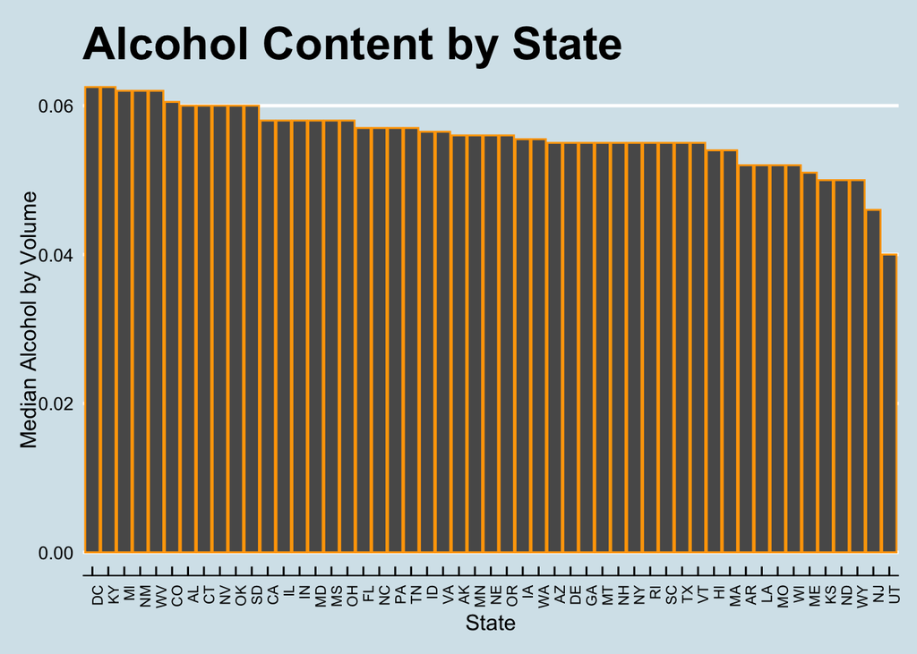

```r
medianABVandIBU <- beerAndBrew %>% group_by(state) %>% summarize(medianStateABV = median(ABV, na.rm = TRUE),
            medianStateIBU = median(IBU, na.rm = TRUE), count = n())

meanABVandIBU <- beerAndBrew %>% group_by(state) %>% summarize(meanStateABV = mean(ABV, na.rm = TRUE),
                                                                 meanStateIBU = mean(IBU, na.rm = TRUE), count = n())

medianABVandIBU <- as.data.frame(medianABVandIBU)

medianABVandIBU %>% ggplot(mapping = aes(x = reorder(state, -medianStateABV))) +
  geom_bar(aes(weight = medianStateABV), color = "orange") +
  ggtitle("Alcohol Content by State") +
  ylab("Median Alcohol by Volume") + xlab("State") +
  theme_economist() +
  theme(plot.title = element_text(size=25),
        text = element_text(size=12),
        legend.position = "none",
        axis.text.x = element_text(size=8,angle = 90, hjust = 1, vjust = 1),
        axis.text.y = element_text(size=10))
```

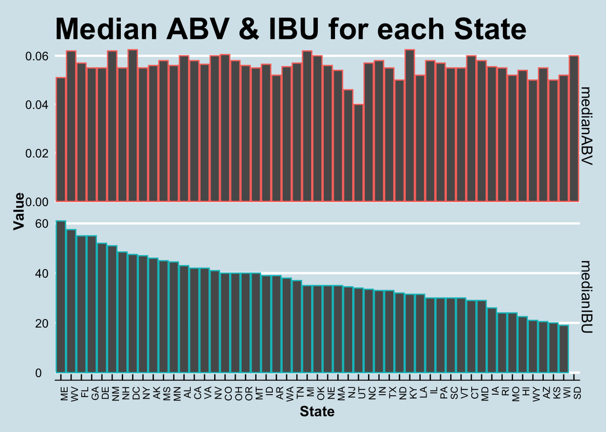

```r
abv <- beerAndBrew %>% group_by(state) %>% summarize(medianABV = median(ABV,na.rm=TRUE))
abv <- data.frame(abv)
ibu <- beerAndBrew %>% group_by(state) %>% summarize(medianIBU = median(IBU,na.rm=TRUE))

#Merging median ABV and median IBU data and stacking
df=merge(abv,ibu, by = "state")
dfM=melt(df,id.vars = "state")

na.omit(dfM) %>% ggplot(mapping=aes(x =reorder(state, -value), y = value, color=variable)) +
  geom_col()+
  theme_economist()+
  facet_grid(variable ~ .,scales='free')+
  xlab("State")+
  ylab("Value")+
  labs(color="Variable") +
  ggtitle("Median ABV & IBU for each State") +
  theme(text = element_text(size=10), #labels
        axis.text.x = element_text(size=8,angle = 90, hjust = 1, vjust = 1),
        axis.text.y = element_text(size=10),
        axis.title = element_text(size=12,face="bold"),
        plot.title = element_text(size=25),
        legend.position = "none")
```

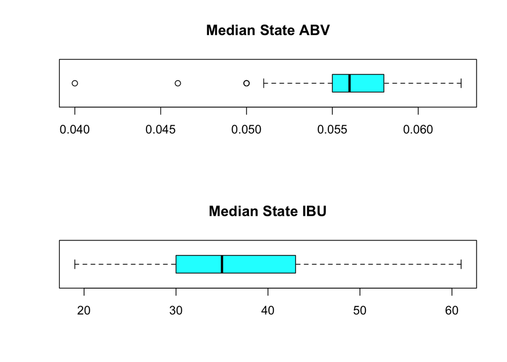

```r
#Boxplots to layer aboved bar charts for presentation.
par(mfrow=c(2,1))
boxplot(medianABVandIBU$medianStateABV, col = "cyan", horizontal = TRUE, main = "Median State ABV")
boxplot(medianABVandIBU$medianStateIBU, col = "cyan", horizontal = TRUE, main = "Median State IBU")
```

```r
dev.off()
```

## (5) Highest ABV and IBU

Which state has the maximum alcoholic (ABV) beer? Which state has the most bitter (IBU) beer?

```r
meanABVandIBU[which.max(meanABVandIBU$meanStateABV),1] #NV
```

```
## # A tibble: 1 x 1
##   state
##   <chr>
## 1 " NV"
```

```r
medianABVandIBU[which.max(medianABVandIBU$medianStateABV),1] #DC
```

```
## [1] " DC"
```

```r
meanABVandIBU[which.max(meanABVandIBU$meanStateIBU),1] #WV
```

```
## # A tibble: 1 x 1
##   state
##   <chr>
## 1 " WV"
```

```r
medianABVandIBU[which.max(medianABVandIBU$medianStateIBU),1] #ME
```

```
## [1] " ME"
```

##### Question 5 - Answer : State with maximum alcohholic beer: NV, State with most bitter beer : WV

## (6) ABV Distribution

Comment on the summary statistics and distribution of the ABV variable.

```r
summary(beerAndBrew$ABV)
```

```
##    Min. 1st Qu.  Median    Mean 3rd Qu.    Max.    NA's
## 0.00100 0.05000 0.05600 0.05977 0.06700 0.12800      62
```

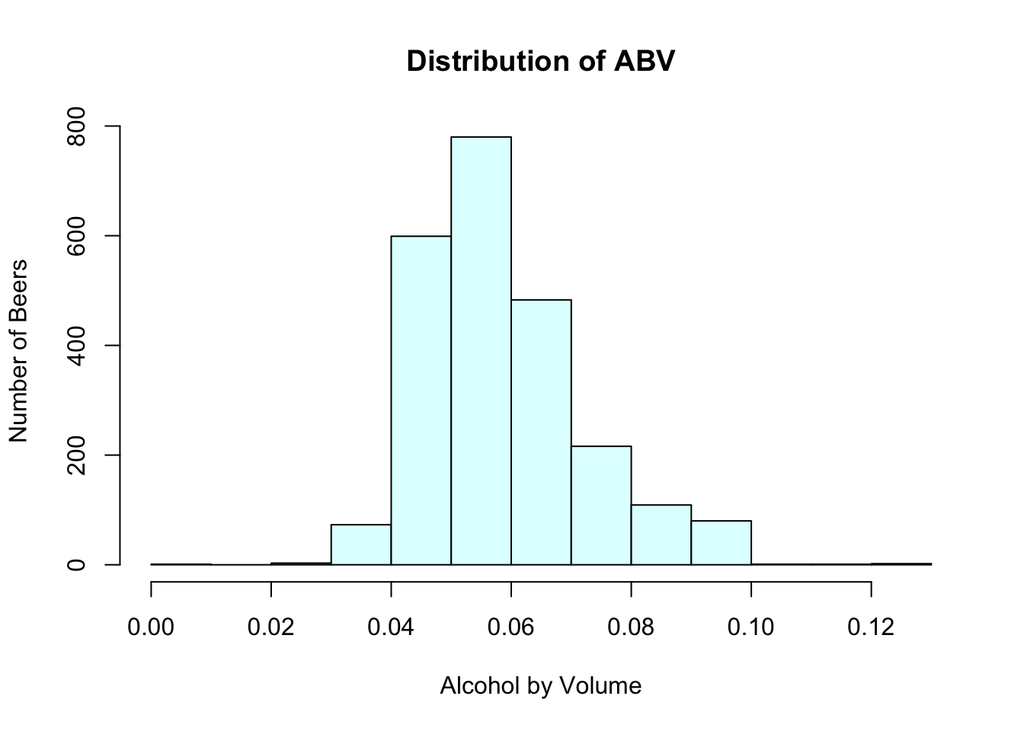

```r
hist(beerAndBrew$ABV, main = "Distribution of ABV", xlab = "Alcohol by Volume",
     ylab = "Number of Beers", col = "light cyan")
```

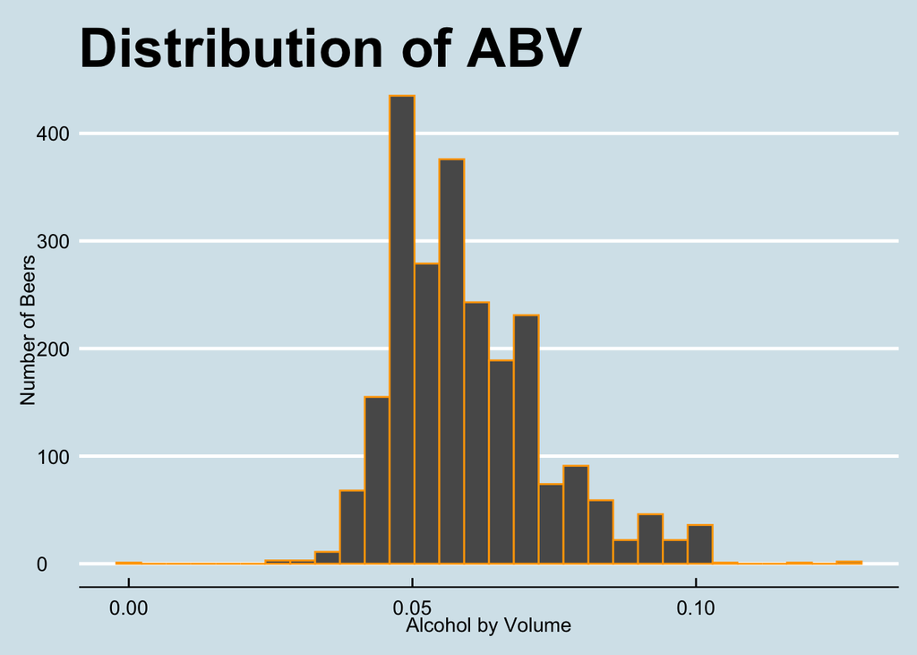

```r
beerAndBrew %>% ggplot(mapping = aes(x= ABV)) +
  geom_histogram(color = "orange") +
  ggtitle("Distribution of ABV") +
  ylab("Number of Beers") + xlab("Alcohol by Volume") +
  theme_economist() +
  theme(plot.title = element_text(size=30))
```

##### Question 6 - Answer : The ABV distribution looks fairly looks normal but a little bit right skewed due to some extreme outliers that are in the 8-10%.

##(7) Bitterness vs Alcoholic Content

Is there an apparent relationship between the bitterness of the beer and its alcoholic content? Draw a scatter plot. Make your best judgment of a relationship and EXPLAIN your answer.

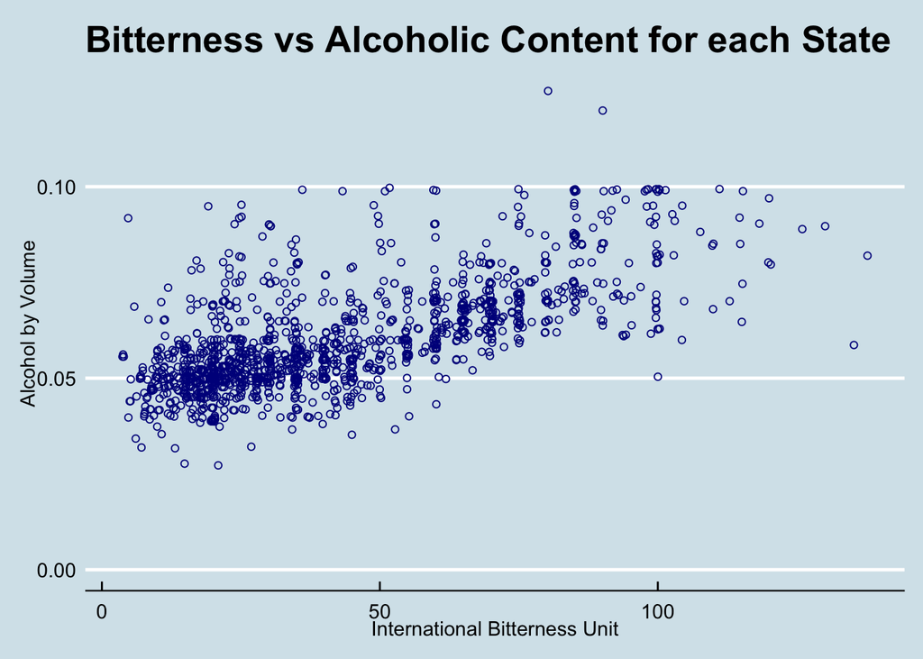

```r
beerAndBrew %>% ggplot(mapping = aes(x= IBU, y = ABV)) +
  geom_point(position = "jitter", color = "dark blue",pch=21) +
  ggtitle("Bitterness vs Alcoholic Content for each State") +
  ylab("Alcohol by Volume") + xlab("International Bitterness Unit") +
  theme_economist() +
  theme(plot.title = element_text(size=20), legend.position = "none")
```

#### Question 7 - Answer : There seems to be a linear relationship between ABV and IBU, meaning ABV goes up, IBU also goes up.

##(8) KNN & Naive Bayes

Budweiser would also like to investigate the difference with respect to IBU and ABV between IPAs (India Pale Ales) and other types of Ale (any beer with “Ale” in its name other than IPA). You decide to use KNN classification to investigate this relationship. Provide statistical evidence one way or the other. You can of course assume your audience is comfortable with percentages … KNN is very easy to understand conceptually.

In addition, while you have decided to use KNN to investigate this relationship (KNN is required) you may also feel free to supplement your response to this question with any other methods or techniques you have learned. Creativity and alternative solutions are always encouraged.

```r
beerAndBrew$Beer_Name2 <- str_replace_all(beerAndBrew$Beer_Name, "\\.", "")
beerAndBrew$Style2 <- str_replace_all(beerAndBrew$Style, "\\.", "")

beerAndBrew$Beer_Name2 <- str_to_upper(beerAndBrew$Beer_Name2)
beerAndBrew$Style2 <- str_to_upper(beerAndBrew$Style2)

#Next seven lines of code must be completed in the order listed.
beerAndBrew$Ale <- "Not Ale"
beerAndBrew$Ale[grep("ALE",ignore.case = TRUE, beerAndBrew$Beer_Name2)] <-  "Ale"
beerAndBrew$Ale[grep("ALE",ignore.case = TRUE, beerAndBrew$Style2)] <- "Ale"
#514 ales found in beer style that are not found in beer name.
beerAndBrew$Ale[grep("INDIA PALE ALE",ignore.case = TRUE, beerAndBrew$Beer_Name2)] <- "IPA"
beerAndBrew$Ale[grep("IPA",ignore.case = TRUE, beerAndBrew$Beer_Name2)] <- "IPA"
beerAndBrew$Ale[grep("INDIA PALE ALE",ignore.case = TRUE, beerAndBrew$Style2)] <-"IPA"
beerAndBrew$Ale[grep("IPA",ignore.case = TRUE, beerAndBrew$Style2)] <- "IPA"
#200 IPA's found in beer stlye that are not found in beer name.

#Changing to factor to view a quick summary of how many IPA, Ale, and Not Ale beers were found.
beerAndBrew$Ale <- as.factor(beerAndBrew$Ale)
summary(beerAndBrew$Ale)
```

```
##     Ale     IPA Not Ale
##    1068     583     759
```

```r
#Saving all the IPA's and other ales into one dataframe by excluding not ale.
Ales <- beerAndBrew[-grep("Not Ale",ignore.case = TRUE, beerAndBrew$Ale),]
Ales <- droplevels(Ales)

summary(is.na.data.frame(Ales))
```

```
##   Brew_ID        Brewery_Name       City           state
##  Mode :logical   Mode :logical   Mode :logical   Mode :logical
##  FALSE:1651      FALSE:1651      FALSE:1651      FALSE:1651
##
##  Beer_Name        Beer_ID           ABV             IBU
##  Mode :logical   Mode :logical   Mode :logical   Mode :logical
##  FALSE:1651      FALSE:1651      FALSE:1607      FALSE:1009
##                                  TRUE :44        TRUE :642
##    Style           Ounces        Beer_Name2        Style2
##  Mode :logical   Mode :logical   Mode :logical   Mode :logical
##  FALSE:1651      FALSE:1651      FALSE:1651      FALSE:1651
##
##     Ale
##  Mode :logical
##  FALSE:1651
##
```

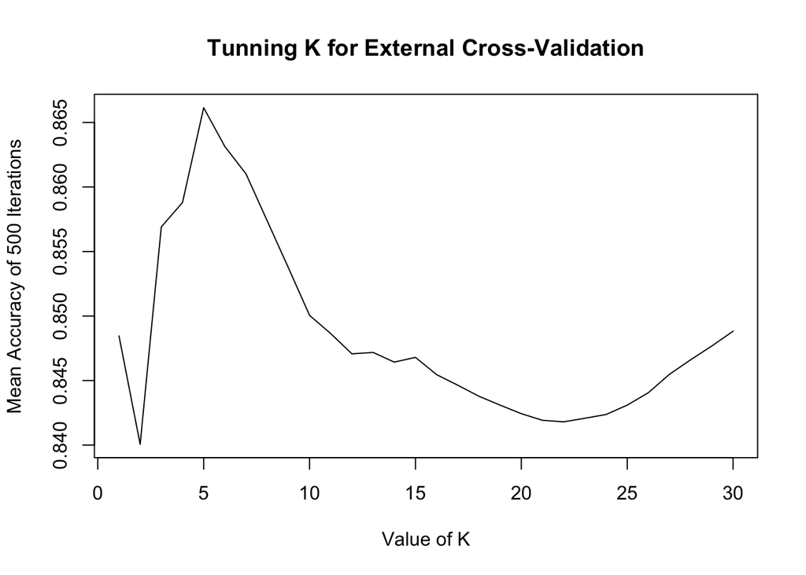

```r
#642 missing IBU values within Ale subset, and 44 missing ABV values within ale subset.
Ales <- na.omit(Ales)


#Tuning K
#***********************************************************************************************
splitPerc = .70
iterations = 500
numks = 30

masterAcc = matrix(nrow = iterations, ncol = numks)

for(j in 1:iterations)
{
  trainIndicesAlesIter = sample(1:dim(Ales)[1],round(splitPerc * dim(Ales)[1]))
  train = Ales[trainIndicesAlesIter,]
  test = Ales[-trainIndicesAlesIter,]
  for(i in 1:numks)
  {
    classifications = knn(train[,c(7,8)],test[,c(7,8)],train$Ale, prob = TRUE, k = i)
    CM = confusionMatrix(table(classifications,test$Ale))
    masterAcc[j,i] = CM$overall[1]
  }
}

MeanAcc = colMeans(masterAcc)

plot(seq(1,numks,1),MeanAcc, type = "l", main = "Tunning K for External Cross-Validation",
     xlab = "Value of K", ylab = "Mean Accuracy of 500 Iterations")
```

```r
which.max(MeanAcc)
```

```
## [1] 5
```

```r
#***********************************************************************************************

#K-nn with tuned K = 5
set.seed(6)
trainIndiciesAles = sample(1:dim(Ales)[1],round(splitPerc * dim(Ales)[1]))
trainAles = Ales[trainIndiciesAles,]
testAles = Ales[-trainIndiciesAles,]
confusionMatrix(table(knn(trainAles[,c(7,8)],testAles[,c(7,8)],trainAles$Ale, k = 5),testAles$Ale))
```

```
## Confusion Matrix and Statistics
##
##
##       Ale IPA
##   Ale 167  22
##   IPA  21  93
##
##                Accuracy : 0.8581
##                  95% CI : (0.8136, 0.8954)
##     No Information Rate : 0.6205
##     P-Value [Acc > NIR] : <2e-16
##
##                   Kappa : 0.6982
##
##  Mcnemar's Test P-Value : 1
##
##             Sensitivity : 0.8883
##             Specificity : 0.8087
##          Pos Pred Value : 0.8836
##          Neg Pred Value : 0.8158
##              Prevalence : 0.6205
##          Detection Rate : 0.5512
##    Detection Prevalence : 0.6238
##       Balanced Accuracy : 0.8485
##
##        'Positive' Class : Ale
##
```

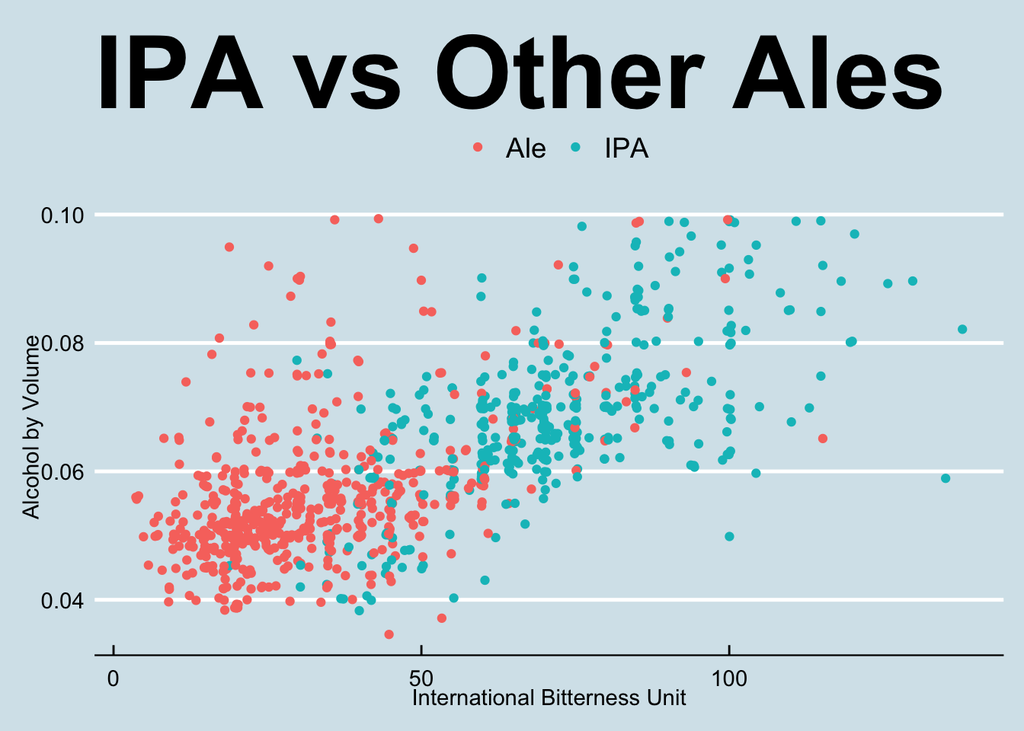

```r
#Scatterplot of IBU vs ABV for IPA vs Other Ales
Ales %>% ggplot(mapping = aes(x= IBU, y = ABV, color = Ale)) +
  geom_point(position = "jitter") +
  ggtitle("IPA vs Other Ales") +
  ylab("Alcohol by Volume") + xlab("International Bitterness Unit") +
  theme_economist() +
  theme(plot.title = element_text(size=50), legend.title = element_blank())
```

```r
#Using Naive Bayes
model = naiveBayes(trainAles[,c(7,8)],as.factor(trainAles$Ale), laplace=1)
table(predict(model,testAles[,c(7,8)]),as.factor(testAles$Ale))
```

```
##
##       Ale IPA
##   Ale 166  24
##   IPA  22  91
```

```r
CMnb=confusionMatrix(table(predict(model,testAles[,c(7,8)]),as.factor(testAles$Ale)))
CMnb
```

```
## Confusion Matrix and Statistics
##
##
##       Ale IPA
##   Ale 166  24
##   IPA  22  91
##
##                Accuracy : 0.8482
##                  95% CI : (0.8027, 0.8867)
##     No Information Rate : 0.6205
##     P-Value [Acc > NIR] : <2e-16
##
##                   Kappa : 0.6766
##
##  Mcnemar's Test P-Value : 0.8828
##
##             Sensitivity : 0.8830
##             Specificity : 0.7913
##          Pos Pred Value : 0.8737
##          Neg Pred Value : 0.8053
##              Prevalence : 0.6205
##          Detection Rate : 0.5479
##    Detection Prevalence : 0.6271
##       Balanced Accuracy : 0.8371
##
##        'Positive' Class : Ale
##
```

##### Question 8 - Answer: Knn produces slightly higher Accuracy than NB model

## (9) Useful Inference

Knock their socks off! Find one other useful inference from the data that you feel Budweiser may be able to find value in. You must convince them why it is important and back up your conviction with appropriate statistical evidence.

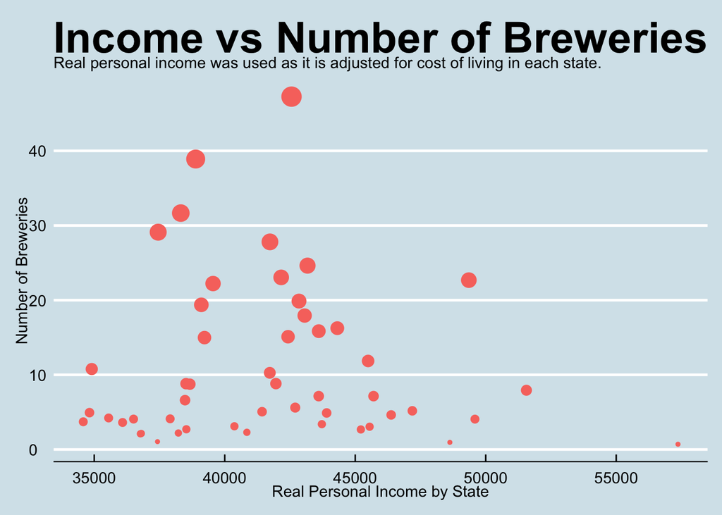

```r
RPI2012 <- na.omit(read.csv("~/Desktop/SMU Project/RPI.csv", header = TRUE))
RPI2012 <- RPI2012[c(2,12,13)]
names(RPI2012)[1] = "region"
names(RPI2012)[2] = "RPI_2012"
names(RPI2012)[3] = "RPI_Bracket"
RPI2012$region <- str_to_lower(RPI2012$region)

breweryByRegion <- merge(RPI2012, breweryByRegion, by = "region", all.y = TRUE)

#Scatterplot of Income vs Number of Breweries by State
breweryByRegion %>% ggplot(mapping = aes(x= RPI_2012, y = numBreweries, size = numBreweries, color = "light red")) +
  geom_point(position = "jitter") +
  guides(size=FALSE) + #Removes the legend for size
  ggtitle("Income vs Number of Breweries by State") +
  labs(subtitle = "Real personal income was used as it is adjusted for cost of living in each state.") +
  ylab("Number of Breweries") + xlab("Real Personal Income by State") +
  theme_economist() +
  theme(plot.title = element_text(size=30), legend.position = "none")
```

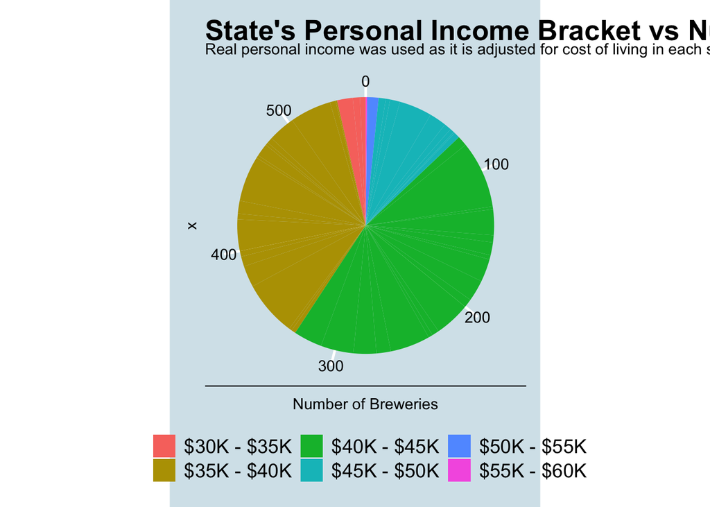

```r
#Pie chart of Breweires by Income Bracket
breweryByRegion %>% ggplot(mapping = aes(x="", y=numBreweries, fill=RPI_Bracket)) +
  geom_bar(stat="identity", width=1) +
  coord_polar("y", start=0) +
  ggtitle("State's Personal Income Bracket vs Number of Breweries") +
  labs(subtitle = "Real personal income was used as it is adjusted for cost of living in each state.") +
  ylab("Number of Breweries") +
  theme_economist() +
  theme(plot.title = element_text(size=20), legend.position = "bottom", legend.title = element_blank())
```

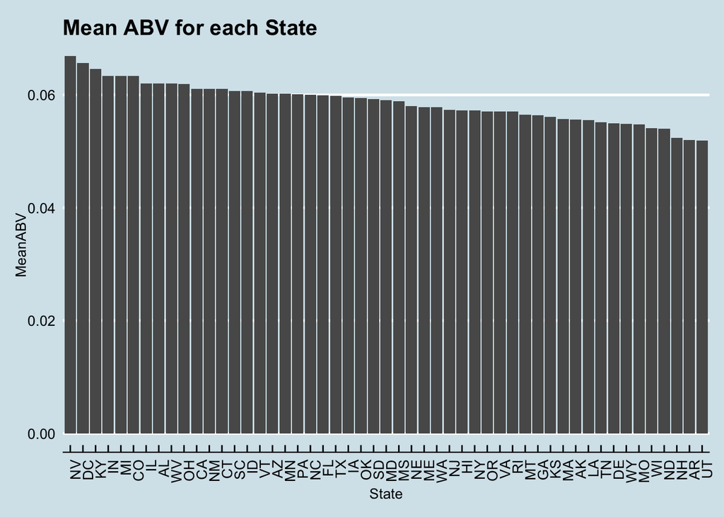

```r
#Per Capita
#Listing ABV of all Budweiser brands
#Bud Light : 4.2%
#Budweiser : 5%
#Bud Ice : 5.5%
#Bud light lime : 4.2%
#Average of these beers : 4.725%

#Find states that have mean ABV values of between 4% and 5%
Meanabv <- beerAndBrew %>% group_by(state) %>% summarize(meanABV = mean(ABV,na.rm=TRUE))
Meanabv=data.frame(Meanabv)

Meanabv %>% ggplot(aes(x = reorder(state, -meanABV), y = meanABV))+
  geom_col()+
  labs(y="MeanABV", x = "State")+
  ggtitle("Mean ABV for each State")+
  theme_economist()+
  theme(text = element_text(size=10),axis.text.x = element_text(angle = 90, hjust = 1, vjust = 1))
```

```r
filtered <- Meanabv %>% filter(meanABV < 0.056)
arrange(filtered,meanABV)
```

```
##    state    meanABV
## 1     UT 0.05188462
## 2     AR 0.05200000
## 3     NH 0.05237500
## 4     ND 0.05400000
## 5     WI 0.05405882
## 6     MO 0.05479487
## 7     WY 0.05486667
## 8     DE 0.05500000
## 9     TN 0.05516667
## 10    LA 0.05552632
## 11    AK 0.05564000
## 12    MA 0.05568293
```

```r
#Alcohol consumption per capita
percapita <- read.csv("~/Desktop/SMU Project/Percapita.csv", header=TRUE)

filtered1 <- percapita %>% filter(Gallons.per.capita > 1.27)
arrange(filtered1,-Gallons.per.capita)
```

```
##    state Gallons.per.capita
## 1     NH               1.79
## 2     MT               1.60
## 3     VT               1.53
## 4     ND               1.50
## 5     SD               1.37
## 6     NV               1.35
## 7     ME               1.34
## 8     WI               1.29
## 9     PA               1.29
## 10    HI               1.28
```

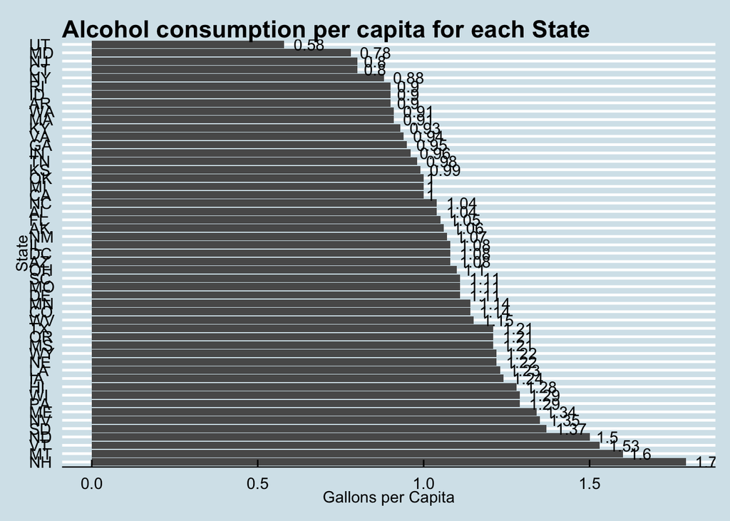

```r
percapita %>% ggplot(aes(x = reorder(state, -Gallons.per.capita), y = Gallons.per.capita))+
  geom_col()+
  theme(text = element_text(size=10),axis.text.x = element_text(angle = 90, hjust = 1, vjust = 1))+
  labs(y="Gallons per Capita", x = "State")+
  ggtitle("Alcohol consumption per capita for each State")+
  coord_flip() +
  theme_economist() +
  geom_text(aes(label=Gallons.per.capita), position=position_dodge(width=0.9), hjust=-0.3)
```

```r
#Heat map of drink volume per capita
str(percapita)
```

```
## 'data.frame':    51 obs. of  2 variables:
##  $ state             : chr  "NH" "MT" "VT" "ND" ...
##  $ Gallons.per.capita: num  1.79 1.6 1.53 1.5 1.37 1.35 1.34 1.29 1.29 1.28 ...
```

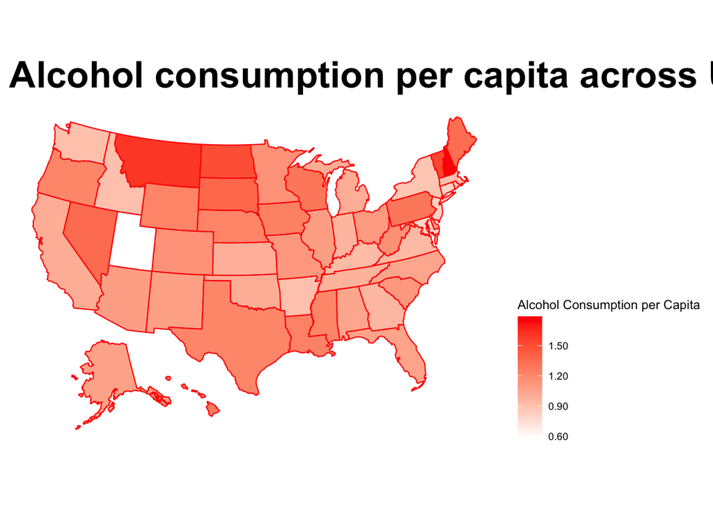

```r
plot_usmap(data = percapita, values = "Gallons.per.capita", color = "red") +
  scale_fill_continuous(low = "white", high = "red", name = "Alcohol Consumption per Capita", label = scales::comma) +
  theme(legend.position = "right")+
  labs(title = "Alcohol consumption per capita across United States")+
  theme(plot.title = element_text(size = 26, face = "bold"))
```

### Question 9 - Findings and Conclusion

##### * From the scatterplot of Income vs Number of Breweries by State, we surprisingly find that breweries are concentrated around low-middle income region

##### * We looked for states with low ABV % that are similar to those of Budweiser’s products.

##### * Also looked for states with high alcohol consumption per capita.

##### * Midwesterners drink more beer than other regions across the United States, while Northeasterners drink the least. However, New Hampshire state had the highest alcohol consumption per capita likely due to the state’s low tax on alcohol. Meanwhile, Utah unsurprisingly drinks the least amount of beer per capita, as the predominantly Mormon state largely abstains from alcohol. source: https://vinepair.com/articles/map-states-drink-beer-america-2020/

### Below are three candidates for potential investment opportunities.

##### * New Hampshire has low ABV %, has only 3 breweries in the state, Has highest alcohol consumption per capita -> Very good market opportunity for Budweiser

##### * North Dakota has 4th lowest ABV%m and 4th highest alcohol consumption

##### * Wisconsin has 5th lowest ABV% and 9th highest alcohol consumption